### Pre-processing and clean-up

This first step downloads the required libraries and data files.

```r
## required libraries
library(ggplot2)
library(dplyr)
## download file
zipurl <- "http://d396qusza40orc.cloudfront.net/repdata%2Fdata%2Factivity.zip"
download.file(zipurl, "temp.zip", mode="wb")
unzip("temp.zip", "activity.csv")
dd <- read.table("activity.csv", sep=",", header=T)
```

Next, we remove NAs and take a quick look at the data using the R summary command.

```r
## remove NAs
d <- dd[complete.cases(dd), ]

## quick look
summary(d)
```

```
##      steps               date          interval
##  Min.   :  0.0   2012-10-02:  288   Min.   :   0
##  1st Qu.:  0.0   2012-10-03:  288   1st Qu.: 589
##  Median :  0.0   2012-10-04:  288   Median :1178
##  Mean   : 37.4   2012-10-05:  288   Mean   :1178
##  3rd Qu.: 12.0   2012-10-06:  288   3rd Qu.:1766
##  Max.   :806.0   2012-10-07:  288   Max.   :2355
##                  (Other)   :13536
```

### What is mean total number of steps taken per day?

The code chunk below creates a summary of the steps taken per day, creates a histogram, and calculates both the **mean** and **median** steps per day.

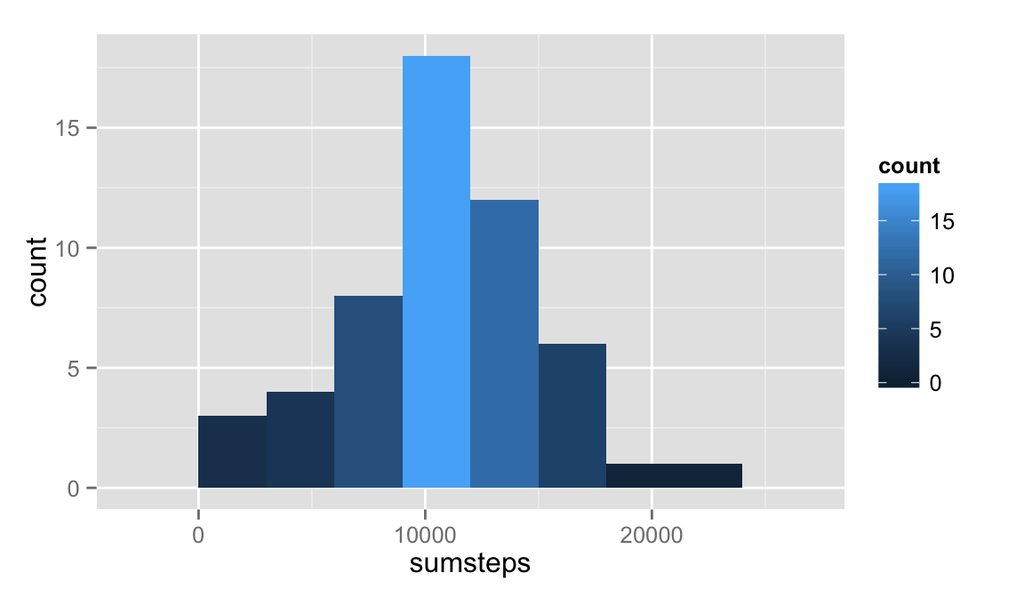

```r
## summarize data
ds <- d %>% group_by(date) %>% summarise(sumsteps=sum(steps))

## histogram
dsum <- ggplot(data=ds, aes(x=sumsteps))
dsum + geom_histogram(aes(fill=..count..), binwidth=3000)
```

```r
## mean number of steps taken per day
dmean <- mean(ds$sumsteps) ## mean of total number of steps
dmean
```

```
## [1] 10766
```

```r
dmedian <- median(ds$sumsteps) ## median of total number of steps
dmedian
```

```
## [1] 10765
```

### What is the average daily activity pattern?

Make a time series plot (i.e. type = “l”) of the 5-minute interval (x-axis) and the average number of steps taken, averaged across all days (y-axis).

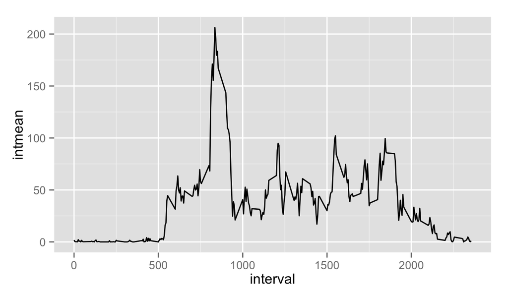

```r
## summarize and plot
dint <- d %>% group_by(interval) %>% summarise(intmean=mean(steps))

dintline <- ggplot(data=dint, aes(x=interval, y=intmean))
  dintline + geom_line()
```

Which 5-minute interval, on average across all the days in the dataset, contains the maximum number of steps?

```r
## max five minute interval
subset(dint, intmean == max(intmean), select=c(interval, intmean))
```

```
## Source: local data frame [1 x 2]
##
##   interval intmean
## 1      835   206.2
```

### Imputing missing values

**Processing**

```r
nas <- is.na(d) ## create NA index
dcln <- merge(d, dint, by="interval") ## merge in NA index
dcln$stepsx <- as.numeric(dcln$steps)
my.na <- is.na(dcln$steps)
dcln$stepsx[my.na] <- dcln$intmean[my.na] ## replace NAs with mean value
```

### Histogram of total number of steps taken per day

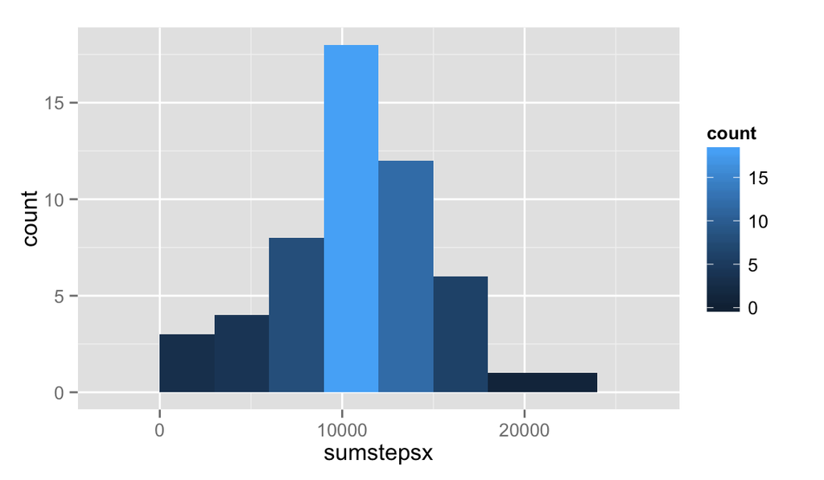

```r
dclns <- dcln %>% group_by(date) %>% summarise(sumstepsx=sum(stepsx)) ## summary

dclnshist <- ggplot(data=dclns, aes(x=sumstepsx))
dclnshist + geom_histogram(aes(fill=..count..), binwidth=3000)
```

```r
dmeanx <- mean(dclns$sumstepsx) ## mean of total number of steps
dmeanx
```

```
## [1] 10766
```

```r
dmedianx <- median(dclns$sumstepsx) ## median of total number of steps
dmedianx
```

```
## [1] 10765
```

Calculate difference between the mean and median of the original dataset vs. the revised dataset with inputted values

```r
## difference in mean and median values with and without inputing
dmeandiff <- dmean - dmeanx
dmediandiff <- dmedian - dmedianx
```

**original mean - inputted mean = 0**

**original median - inputted median = 0**

### Are there differences in activity patterns between weekdays and weekends?

Create a new factor variable in the dataset with two levels - “weekday” and “weekend” indicating whether a given date is a weekday or weekend day.

The differences are clear when looking at the two line plots below.

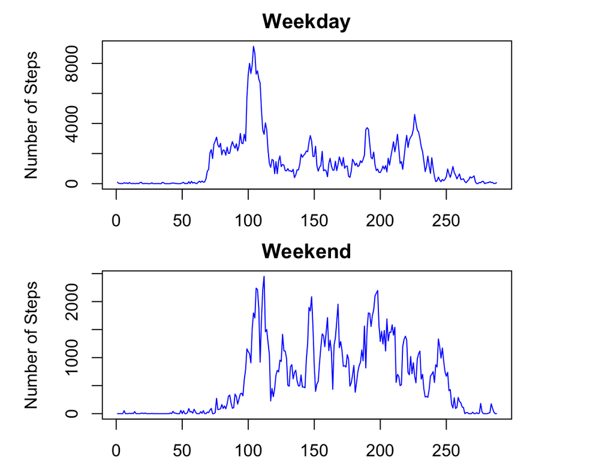

```r
## create weekeday variable
dcln$week <- weekdays(as.Date(dcln$date))

## subset into the weekday and weekend datasets
dclnweek <- subset(dcln, week == "Monday" | week == "Tuesday" | week == "Wednesday" |
                     week == "Thursday" | week == "Friday") ## week subset
dclnwend <- subset(dcln, week == "Saturday" | week == "Sunday") ## weekend subset

## create sum of steps data by interval
dclnweeksum <- dclnweek %>% group_by(interval) %>% summarize(sumstepsx=sum(stepsx))
dclnwendsum <- dclnwend %>% group_by(interval) %>% summarize(sumstepsx=sum(stepsx))

## differences between weekday and weekend activities
par(mfrow=c(2, 1), mar=c(2, 5, 2, 5))
plot(dclnweeksum$sumstepsx, type="l", col="blue", xlab="Interval", ylab="Number of Steps")
  title(main="Weekday", font.main=2)
plot(dclnwendsum$sumstepsx, type="l", col="blue", xlab="Interval", ylab="Number of Steps")
  title(main="Weekend", font.main=2)
```